# My visual data story-Some Observation of YouTube Recommendation

I created three charts to explore patterns in my YouTube recommendation data. My main focus was on whether recommended videos changed between March and May, whether certain categories used clickbait content more frequently than others, and whether the time of day was related to video length.

## Recommendation by Category

The following chart shows that clickbait headlines are more prevalent in certain video categories than in others. In my data, the education, news, and music categories have a higher number of clickbait headlines than several other categories. This suggests that the use of clickbait headlines can vary depending on the content type. However, in terms of proportion, education, news, and games are probably the three channels with the highest proportion of clickbait headlines.

[figure not shown]

Recommendation categories and clickbait status

## Video Length and Time of Day

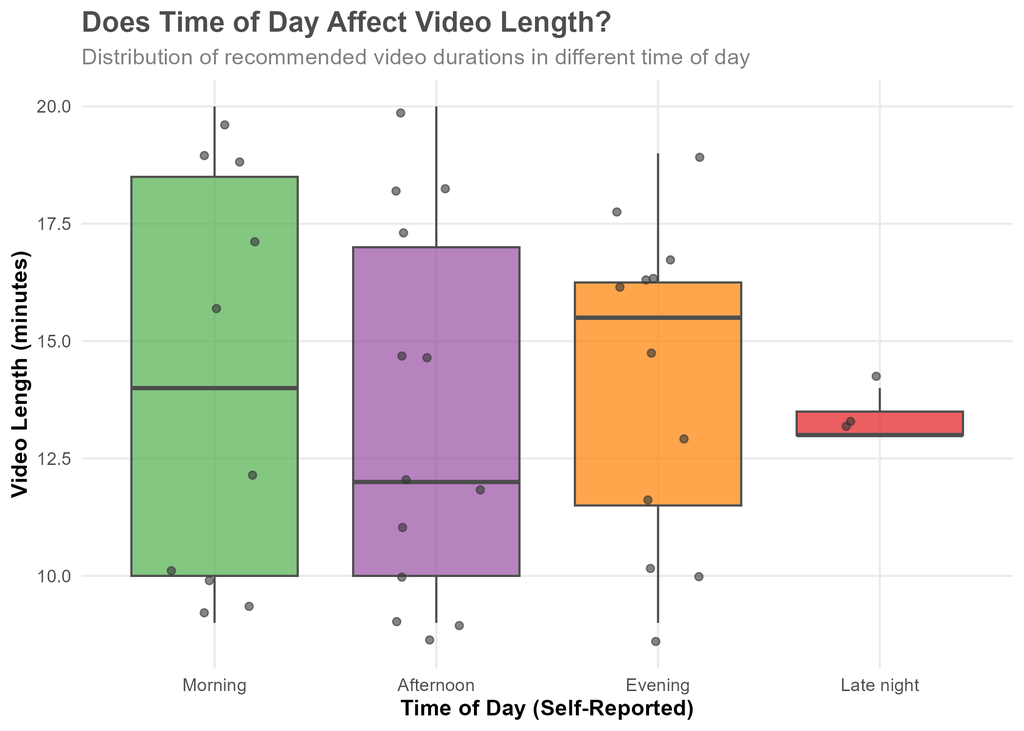

## Tracking algorithm in March and May

I collected this data in two phases to observe whether the algorithm changed over time. This graph shows that the average duration of the recommended videos decreased slightly from March to May. Although the change was small, it indicates that the recommendation pattern was not entirely stable between the two data collection phases. Because I wanted to compare the average video duration between the two data collection phases, I used a bar chart to visually illustrate the difference.

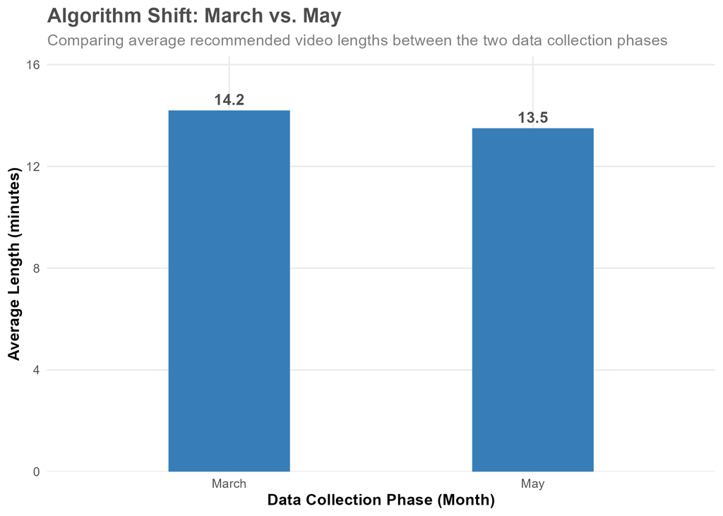

Average video length comparison